# Homework 4

Logan Caraco

```r
library(ggplot2)
library(dplyr)

library(magrittr)
```

# 1. Cars

Consider the cars data which contains the sales price and other information for used Ford cars in St Paul and Dallas. To begin, we can model the price of a car by its mileage and age (in years) without an interaction:

```r
cars <- read.csv("http://www.macalester.edu/~ajohns24/data/FordsSub.csv")
car_model_1 <- lm(Price ~ Mileage + Age, cars)
summary(car_model_1)$coefficients
```

```
##                  Estimate   Std. Error   t value      Pr(>|t|)
## (Intercept)  1.581683e+04 2.914668e+02 54.266314 4.188908e-137
## Mileage     -6.888903e-02 7.187744e-03 -9.584234  1.220109e-18
## Age         -4.809437e+02 8.168277e+01 -5.887946  1.304907e-08
```

By not including an interaction term, the above model assumed that the association between price and mileage does not differ by the age of the car. However, this assumption appears to be false. Instead, consider a model that includes an interaction between mileage and age:

```r
car_model_2 <- lm(Price ~ Age * Mileage, cars)
summary(car_model_2)$coefficients
```

```
##                  Estimate   Std. Error   t value      Pr(>|t|)
## (Intercept)  1.895467e+04 3.250928e+02  58.30543 1.061880e-143
## Age         -1.460909e+03 9.680060e+01 -15.09194  1.223559e-36
## Mileage     -1.219915e-01 6.793278e-03 -17.95768  2.776720e-46
## Age:Mileage  1.159252e-02 8.768120e-04  13.22122  2.405595e-30
```

`Price = 18950 - 1461*Age - 0.122*Mileage + 0.012 Age*Mileage`

1. Interpret the intercept coefficient, 18950. (This actually makes sense in this model!)

*A brand new car (Age, Mileage = 0) has a starting price of $18,950.*

```r
predict(car_model_2, newdata = data.frame(Age = 5, Mileage = 1e5))
```

```
##        1
## 5247.244
```

# 2. Car interactions

By including an interaction term, `car_model_2` assumes that the association between price and mileage may differ depending on the age of the car. Let’s explore what this means in practice.

1. Use `car_model_2` to construct formulas for the relationships between price and mileage for cars of different ages. Each of these should be of the form `Price = a + b Mileage` where you specify `a` and `b`. The first one is done for you. Complete the others using a similar technique.
- 1 year old cars

$$\begin{align} Price &=18950−1461∗1−0.122∗ Mileage+0.012∗1∗ Mileage \\ &=(18950−1461∗1)+(−0.122+0.012∗1) Mileage \\ &=17489−0.11 Mileage \end{align}$$

*5 year old cars

$$\begin{align} \texttt{Price} &= 18950 − 1461 ∗ 5 − 0.122 ∗ \texttt{Mileage} + 0.012 ∗ 5 ∗ \texttt{Mileage} \\
&=(18950 − 1461 ∗ 5) + (−0.122 + 0.012 ∗ 5) * \texttt{Mileage} \\
&=11645 − 0.062 * Mileage \end{align}$$

*10 year old cars

$$\begin{align} \texttt{Price} &= 18950 − 1461 ∗ 10 − 0.122 ∗ \texttt{Mileage} + 0.012 ∗ 10 ∗ \texttt{Mileage} \\
&=(18950 − 1461 ∗ 10) + (−0.122 + 0.012 ∗ 10) * \texttt{Mileage} \\
&=4340 − 0.002 * Mileage \end{align}$$

The positive coefficient means that they are multicolinear, and both are negative contributers to the price of the car. In other words, in order to get an accurate price for the car, accounting only for both age and mileage would underestimate the value, so a little value needs to be added if the age and mileage are non-zero.

# 3. Politics

In 2002 John McCain and John Kerry proposed new auto standards that would have forced manufacturers to increase fuel economy. Carl Levin proposed an amendment to the proposal that would delay any required increase in fuel economy. Hence a YES vote on the Levin amendment was good news for manufacturers. Senators also received contributions from auto manufacturers in 2002. This begs the questions: Who received the most auto contributions? Did it differ by political affiliation? How, if at all, were senators’ votes tied to their political affiliations and received auto contributions? In order to answer these questions, we’ll use the data set senators:

```r
senators <- read.csv("http://www.macalester.edu/~ajohns24/data/Senate.csv")
# Define a variable Affirmed that is TRUE only if voted YES
senators %<>% mutate(Affirmed = Vote == 1)
```

The senators data contains the following measurements on each senator:

| Variable | Description |
| --- | --- |
| `Vote` | 1 or 0 (YES / NO) |
| `AutoCont` | dollars received from auto manufacturers |
| `Party` | `D` (Democrat) or `R` (Republican) |
| `others` | other variables indicate the senators’ names & states |

1. There are 100 senators, 2 from each state. Using dplyr() functions, find the following summary statistics:
- the number of 2002 senators that were Democrats

```r
senators %>%
  filter(Party == "D") %>%
  count
```

```
##    n
## 1 51
```

- the number of senators that voted for the amendment

```r
senators %>%
  filter(Affirmed) %>%
  count
```

```
##    n
## 1 62
```

2. Construct and comment on a univariate visualization of the received contributions (AutoCont).

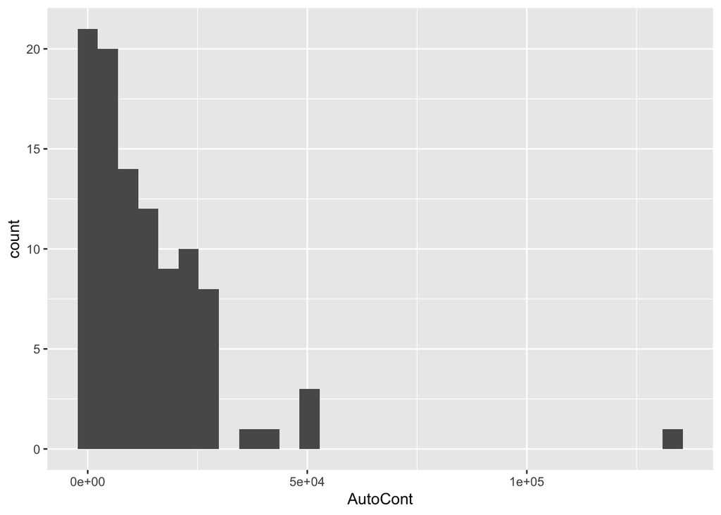

```r
senators %>%
  ggplot(aes(x = AutoCont)) +
  geom_histogram(bins = 30)
```

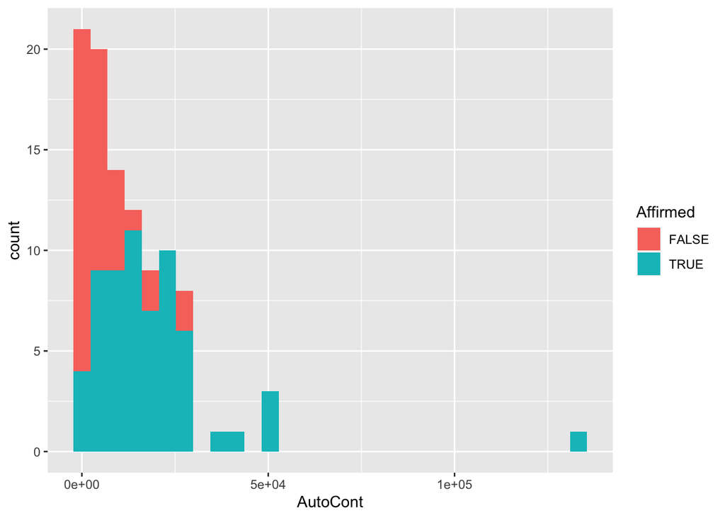

```r
senators %>%
  ggplot(aes(fill = Affirmed, x = AutoCont)) +
  geom_histogram(bins = 30)
```

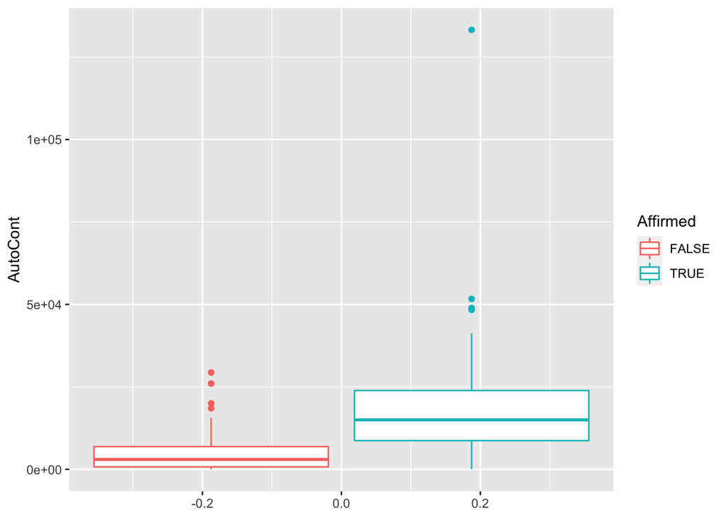

```r
senators %>%
  ggplot(aes(color = Affirmed, y = AutoCont)) +
  geom_boxplot()
```

Those who voted against the amendmnet were paide far less on average, and far less in IQR and outliers, than their pro-amendment counterparts.

3. There’s a clear outlier that received a lot of money from auto manufacturers. Use dplyr code (don’t simply scan the data by eye) to identify the senator, and the state they represent. Extra: If you’re familiar with the auto industry, comment on why this state affiliation might not surprise us.

```r
senators %>%
  arrange(-AutoCont) %>%
  head(1) %>%
  select(LastName, FirstName, State)
```

```
##   LastName FirstName State
## 1   Levin,      Carl    MI
```

Carl Levin was the senator who proposed the amendment, and Michigan is a huge state for auto manufacturing plants.

4. Create `senators_sub`, a subset of the data that does not include this outlier. Confirm that the properties of your `senators_sub` data set match those below. **IMPORTANT: Use the `senators_sub` data for the remainder of the homework.**

```r
senators_sub <- senators %>%
  filter(AutoCont != max(AutoCont))

# It appears there is an extra variable? dim = 99 x 7 not 99 x 6
dim(senators_sub)
```

```
## [1] 99  7
```

```r
# The mean is correct!
senators_sub %>%
  summarize(mean(AutoCont))
```

```
##   mean(AutoCont)
## 1       12599.77
```

# 4. Contributions vs party affiliation

Let’s turn our attention to the relationship between the money senators received from auto manufacturers and their party affiliations.

1. Construct and interpret a visualization of the relationship between `AutoCont` and `Party`. (Again, don’t forget to use `senators_sub`!!!!)

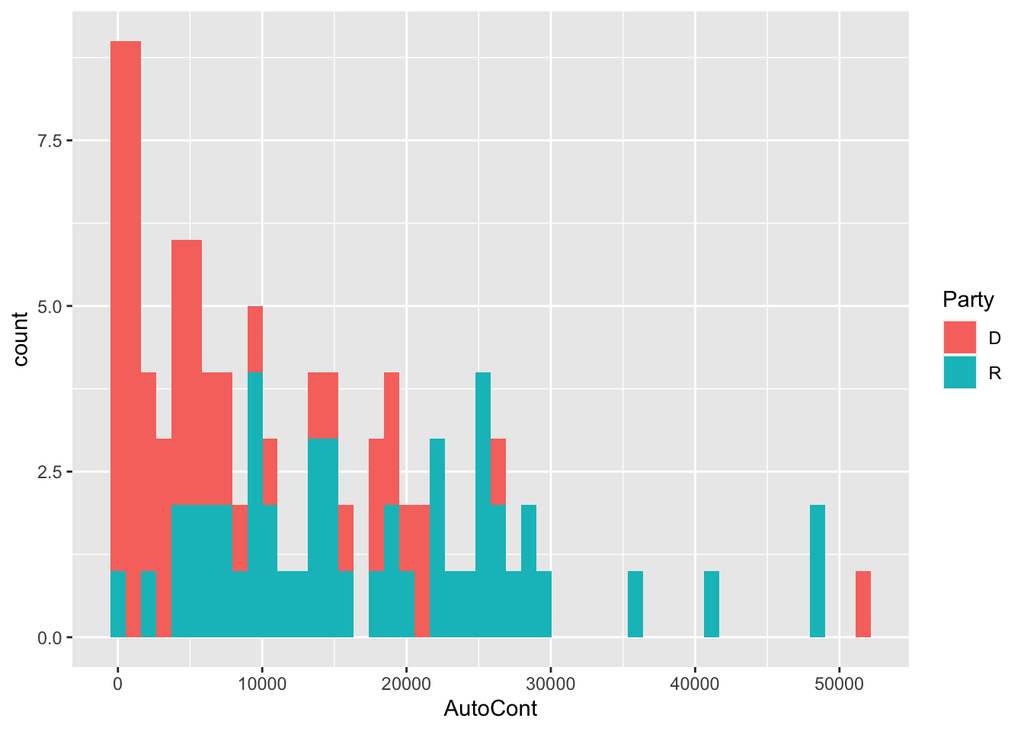

```r
senators_sub %>%
  ggplot(aes(fill = Party, x = AutoCont)) +
  geom_histogram(bins = 50)
```

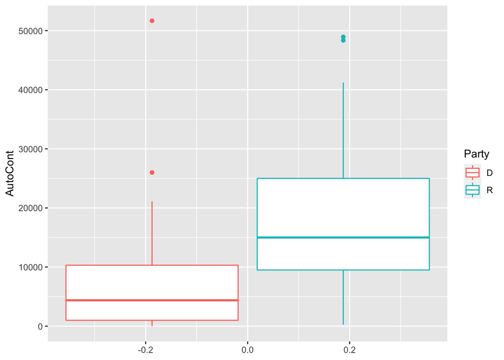

```r
senators_sub %>%
  ggplot(aes(color = Party, y = AutoCont)) +
  geom_boxplot()
```

Democrats were paid far less than republicans in almost every measure.

2. Calculate the average `AutoCont` received by each party.

```r
senators_sub %>%
  group_by(Party) %>%
  summarise(mean(AutoCont))
```

```
## # A tibble: 2 x 2
##   Party `mean(AutoCont)`
## * <chr>            <dbl>
## 1 D                7520.
## 2 R               17783.
```

3. Construct a model of `AutoCont` by `Party.` Include a model summary table.

```r
cont_vs_party_model <- lm(AutoCont ~ Party, data = senators_sub)
summary(cont_vs_party_model)$coef
```

```
##             Estimate Std. Error  t value     Pr(>|t|)
## (Intercept)  7520.28   1478.445 5.086613 1.779394e-06
## PartyR      10262.64   2101.478 4.883534 4.103472e-06
```

4. Interpret the `PartyR` coefficient.

If the party is Republican, then contribution tends to be about $10k higher than a democratic counterpart.

# 5 Votes vs party affiliation

More importantly, we’re interested in modeling senators’ votes. Don’t forget to use the `senators_sub` data in this analysis!

1. Construct and interpret a visualization of the relationship between senators’ votes, their party affiliations, and the amount of money they received from auto manufacturers. NOTE: Use factor(Vote) instead of Vote to treat 0/1 as categories, not numbers.

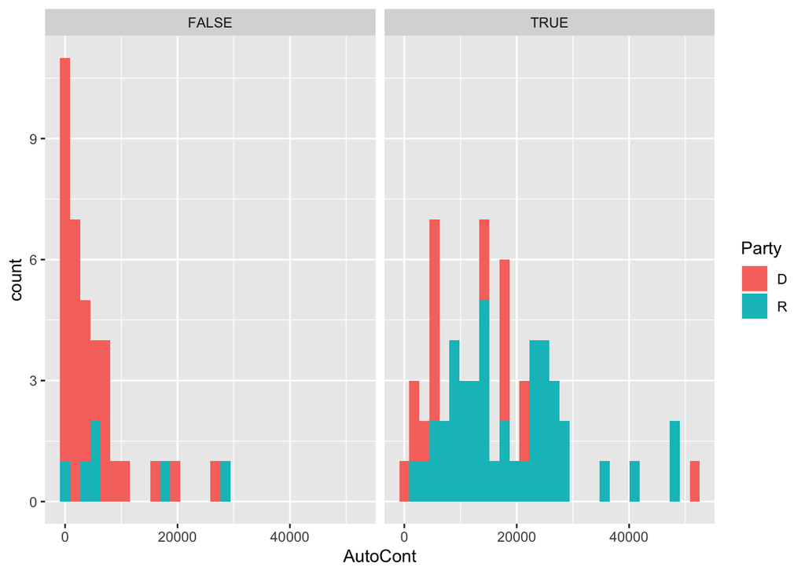

```r
senators_sub %>%
  ggplot(aes(fill = Party, x = AutoCont)) +
  geom_histogram(bins = 30) +
  facet_wrap(~Affirmed)
```

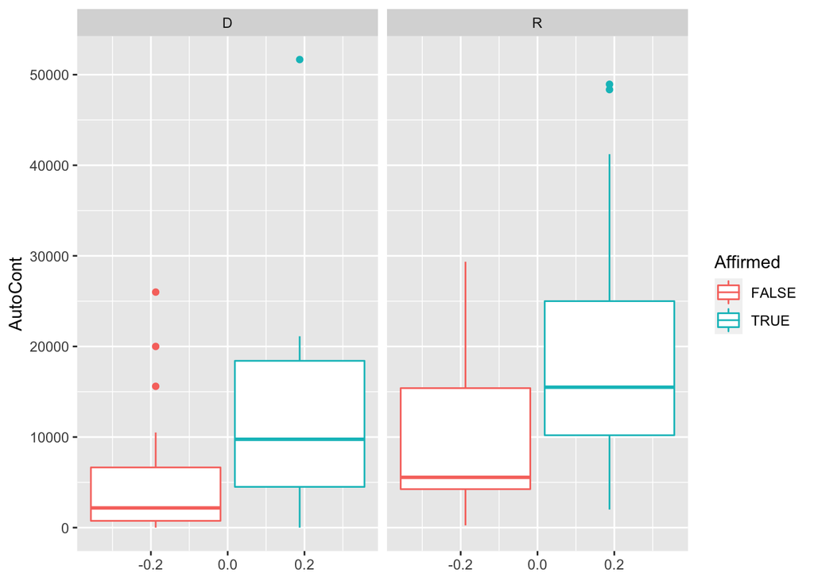

```r
senators_sub %>%
  ggplot(aes(color = Affirmed, y = AutoCont)) +
  geom_boxplot() +
  facet_wrap(~Party)
```

Senators who voted against tended to get far less contributions than those who voted for, and a democrat who voted for the bill tended to get roughly the same contribution as a republican who voted against.

2. Construct a model of `Vote` by `AutoCont` and `Party` without an interaction. Report a model summary table.

```r
vote_by_cont <- glm(Vote ~ AutoCont + Party, senators_sub, family = "binomial")
summary(vote_by_cont)$coefficients
```

```
##                  Estimate   Std. Error   z value     Pr(>|z|)
## (Intercept) -1.4001508486 4.167680e-01 -3.359545 0.0007807104
## AutoCont     0.0001079363 3.595694e-05  3.001822 0.0026836925
## PartyR       1.8810355949 5.715460e-01  3.291136 0.0009978361
```

3. By leaving an interaction term out of the model, what are we assuming? (Don’t just give the definition of interaction. Rather, explain what this means in the context of this analysis.)

We would be assuming that party affiliation has no bearing on contribution, which contradicts what the previous plots suggests.

# 6. Interpreting the model

1. Let p be the probability of a “yes” vote.
- Write down the model equation of p for Democrats.

$$\begin{align}
\log(odds(AutoContr, PartyR)) &= -1.4 + 0.0001 * AutoCont + 1.881 * PartyR \\
P(AutoContr)_{Dem} &= \frac{\exp(-1.4 + 0.0001 * AutoCont)}{1 + \exp(-1.4 + 0.0001 * AutoCont)}
\end{align}$$

- Use the following code to visualize the model (approximately):

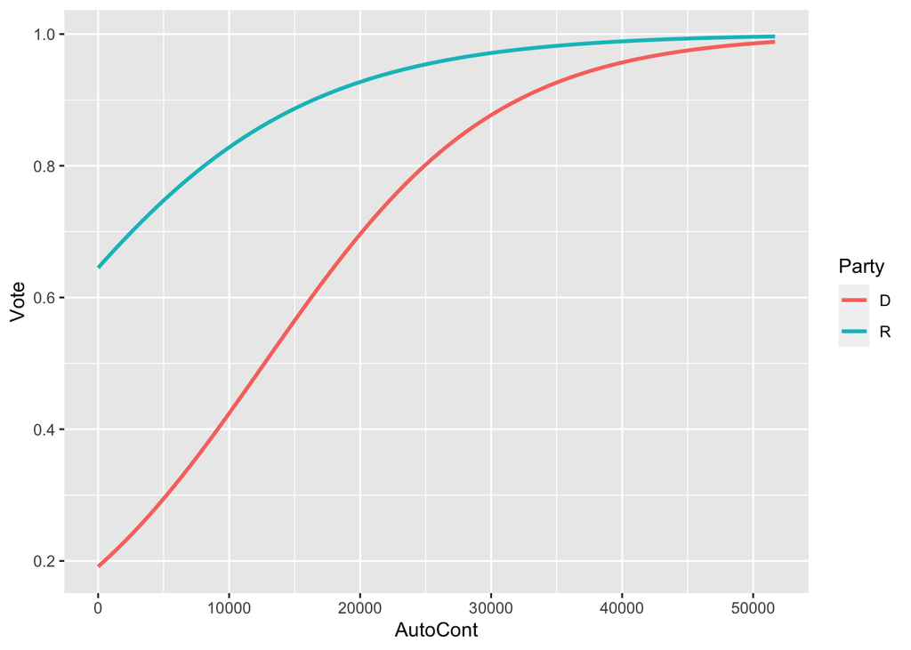

```r
ggplot(senators_sub, aes(x = AutoCont, y = Vote, color = Party)) +
    geom_smooth(method = "glm", method.args = list(family = "binomial"), se = FALSE, fullrange = TRUE)
```

2. Interpret each of the `Intercept`, `AutoCont`, and `PartyR` coefficients in a meaningful way (in the context of the analysis and NOT on a log scale!). Don’t forget to note which variables you’re “controlling for” in these interpretations.

The odds of a democrat with no contributions voting to affirm the amendment are about 0.25. The odds of a republican in the same circumstance voting to affirm are 6.56 higher than the democrat’s. On average, each $1000 donated to a democrat increases their odds of voting for the amendment by just over 11%.

3. For each of the following senators, calculate the probability that they’d vote “yes” for the pro-auto manufacturer amendment. You must show work and do the calculations from scratch, though you can check your work with predict().

```r
# converts from log(odds(E)) to prob(E)
from_log_odds <- function(log_odds) {
  odds <- exp(log_odds)
  return (odds / (odds + 1))
}

# gets the prob of affirmative vote given a contribution and affiliation
prob_for <- function(contribution, is_republican) {
  log_odds <- -1.4 + 0.0001 * contribution + 1.881 * is_republican
  return (from_log_odds(log_odds))
}

# calculates the residual of our manually calculated model vs `predict` on the constructed model
model_residual <- function(contribution, is_republican) {
  party_sym <- if (is_republican == 1) "R" else "D"
  predicted_log_odds <- vote_by_cont %>%
    predict(newdata = data.frame(AutoCont = contribution, Party = party_sym))
  predicted_prob <- from_log_odds(predicted_log_odds)
  guess <- prob_for(contribution, is_republican)
  return (guess - predicted_prob)
}
```

- A Republican that received $1,000 from auto manufacturers.

```r
prob_for(1000, 1)
```

```
## [1] 0.6412975
```

```r
model_residual(1000, 1)
```

```
##            1
## -0.001797122
```

- A Democrat that received $1,000 from auto manufacturers.

```r
prob_for(1000, 0)
```

```
## [1] 0.214165
```

```r
model_residual(1000, 0)
```

```
##            1
## -0.001313196
```

- A Republican that received $20,000 from auto manufacturers.

```r
prob_for(20000, 1)
```

```
## [1] 0.9227991
```

```r
model_residual(20000, 1)
```

```
##          1
## -0.0105687
```

- A Democrat that received $20,000 from auto manufacturers.

```r
prob_for(20000, 0)
```

```
## [1] 0.6456563
```

```r
model_residual(20000, 0)
```

```
##           1
## -0.03538805
```

4. Summarize your observations. What are the main take-home messages from this analysis? What was the relationship between votes, contributions, and party affiliation? NOTE: Had we used data for a vote on a different issue, we might see a different relationship between which party received the most money and how they voted!

There is a high correlation between an affirmative vote and a high contribution, as well as republican affiliation and high contribution.

5. Explain why we can’t use this model to establish a cause-and-effect between money and votes (eg: that more money causes a senator to vote a certain way).

It is also possible that because a senator voted this way, a company then decided to donate more to their campaign because the company’s interests were better served. In other words, we don’t know which came first - the vote or the money.